# Week 3: Bonus Material

Helene Wagner

2017-11-22

## 1. Overview of Bonus Material

### a) Goals

This bonus material shows how to:

- Add sampling locations and hierarchical structure to genind object.
- Estimate inbreeding coefficients.
- Calculate genetic distances among individuals and populations.
- Analyze genetic structure with F statistics (and analogues) and AMOVA.

### b) Data set

Microsatellite data for 181 individuals of Colombia spotted frogs (Rana luteiventris) from 12 populations. Site-level spatial coordinates and attributes. The data are a subsample of the full data set analyzed in Funk et al. (2005) and Murphy et al. (2010). Please see the separate introduction to the data set.

### c) Required R libraries

All required packages should have been installed already when you installed ‘LandGenCourse’.

```r
#require(adegenet)
require(ade4)
require(LandGenCourse)
#require(pegas)
#require(sp)
#require(hierfstat)
#require(PopGenReport)
#require(GeNetIt)
require(dplyr)
#require(poppr)
#require(mmod)
require(tibble)
```

## 2. Add sampling locations and hierarchical structure to genind object

The ‘genind’ object can store non-genetic data in a slot called ‘other’. Here we’ll add spatial coordinates and site data, including the variables that define the hierarchical sampling design, where individual frogs were sampled at ponds (local populations), which are nested within basins, which are nested within drainages.

- **other$latlong**: coordinates in decimal lat/lon format
- **other$xy**: coordinates in UTM format
- **other**: may add any attribute data. Here we’ll add the site data from ralu.site.

### a) Re-create genind object

Adapted from Week 1 tutorial:

```r
data(ralu.loci, package="LandGenCourse")
Frogs <- data.frame(FrogID = paste(substr(ralu.loci$Pop, 1, 3),
                                   row.names(ralu.loci), sep="."), ralu.loci)
Frogs.genind <- adegenet::df2genind(X=Frogs[,c(4:11)], sep=":", ncode=NULL,
                          ind.names= Frogs$FrogID, loc.names=NULL,
                          pop=Frogs$Pop, NA.char="NA", ploidy=2,
                          type="codom", strata=NULL, hierarchy=NULL)
Frogs.genpop <- adegenet::genind2genpop(Frogs.genind)
```

```
##
##  Converting data from a genind to a genpop object...
##
## ...done.
```

### b) Get site-level spatial coordinates and site variables

We import the UTM coordinates from ‘ralu.site@coords’. We use the function ‘spTransform’ to convert them to latlong data (x = Longitude, y = Latitude) to facilitate plotting results on Google maps later in the course. We use ‘get_proj4’ (see Week 2) to define the projection.

```r
data(ralu.site, package="GeNetIt")
coords.longlat <- sp::spTransform(ralu.site, tmaptools::get_proj4("longlat"))@coords
dimnames(coords.longlat)[[2]] <- c("Longitude", "Latitude")
```

The data set ‘ralu.site’ contains 31 sites, whereas here we have only genetic data for 12 sites. Here we use the function ‘left_join’ from the ‘dplyr’ package to extract the coordinates and site data for the sites with frog data.

We first create a data frame ‘Frog.sites’ that contains the population labels and full site names of from the frog genetic data set (ralu.loci). This is necessary here because ralu.site contains only the full site names, whereas ‘Frogs.genind@pop’ uses the short form. To join two tables, we need to have a common identifier variable.

```r
Frogs.sites <- data.frame(Pop=unique(ralu.loci$Pop),
                                       SiteName=unique(ralu.loci$SiteName))
Frogs.sites$n <- as.vector(table(ralu.loci$Pop))
Frogs.sites
```

```
##           Pop       SiteName  n
## 1    Airplane   AirplaneLake 21
## 2    Bachelor BachelorMeadow  8
## 3  BarkingFox BarkingFoxLake 14
## 4         Bob        BobLake 13
## 5       Cache      CacheLake  7
## 6         Egg   EggWhiteLake 17
## 7        Frog   FrogPondLake  9
## 8    GentianL    GentianLake 20
## 9    ParagonL    ParagonLake 19
## 10    Pothole    PotholeLake 13
## 11 ShipIsland ShipIslandLake 17
## 12    Skyhigh    SkyhighLake 23
```

The function ‘left_join’ takes a table x (here: Frog.sites) and a table y (here, we bind the columns from the tables with the latlong coordinates, the UTM coordinates, and the site data from ralu.site into a single dataframe, using function ‘cbind’). The arguent ‘by’ specifies which column in x and in y should be matched. The function ‘left_join’ then finds the rows in table y that match the rows in table x.

Disregard the warning: ‘SiteName’ is a factor in one dataset and character in the other, R is taking care of this.

```r
Frogs.sites <- dplyr::left_join(x=Frogs.sites,
                               y=data.frame(coords.longlat, ralu.site@coords,
                                       ralu.site@data),
                               by = c("SiteName" = "SiteName"))
```

```
## Warning: Column `SiteName` joining factor and character vector, coercing
## into character vector
```

```r
as.tibble(Frogs.sites)
```

```
## # A tibble: 12 x 23
##           Pop       SiteName     n Longitude Latitude coords.x1 coords.x2
##        <fctr>          <chr> <int>     <dbl>    <dbl>     <dbl>     <dbl>
##  1   Airplane   AirplaneLake    21 -114.5977 45.15708  688816.6   5003207
##  2   Bachelor BachelorMeadow     8 -114.6034 45.12016  688494.4   4999093
##  3 BarkingFox BarkingFoxLake    14 -114.6100 45.13047  687938.4   5000223
##  4        Bob        BobLake    13 -114.5828 45.12208  690104.0   4999355
##  5      Cache      CacheLake     7 -114.6008 45.10560  688742.5   4997481
##  6        Egg   EggWhiteLake    17 -114.6032 45.11163  688539.3   4998146
##  7       Frog   FrogPondLake     9 -114.5992 45.11408  688845.2   4998427
##  8   GentianL    GentianLake    20 -114.5856 45.15470  689781.6   5002972
##  9   ParagonL    ParagonLake    19 -114.6186 45.08316  687421.5   4994948
## 10    Pothole    PotholeLake    13 -114.5761 45.16693  690481.4   5004352
## 11 ShipIsland ShipIslandLake    17 -114.6217 45.16529  686908.5   5004064
## 12    Skyhigh    SkyhighLake    23 -114.6077 45.11966  688159.7   4999027
## # ... with 16 more variables: Drainage <chr>, Basin <chr>,
## #   Substrate <chr>, NWI <chr>, AREA_m2 <dbl>, PERI_m <dbl>,
## #   Depth_m <dbl>, TDS <dbl>, FISH <int>, ACB <dbl>, AUC <dbl>,
## #   AUCV <dbl>, AUCC <dbl>, AUF <dbl>, AWOOD <dbl>, AUFV <dbl>
```

### c) Add spatial coordinates and site variables to ‘other’ slot

The data in Frog.sites are at the site level, whereas the genetic data are at the individual level (181 frogs). We can extract the corresponding site data for each frog and add them to the genind object.

```r
tmp <- dplyr::left_join(x=data.frame(Pop=Frogs.genind@pop),
                 y=Frogs.sites,
                 by = c("Pop" = "Pop"))
as.tibble(tmp)
```

```
## # A tibble: 181 x 23
##         Pop     SiteName     n Longitude Latitude coords.x1 coords.x2
##      <fctr>        <chr> <int>     <dbl>    <dbl>     <dbl>     <dbl>
##  1 Airplane AirplaneLake    21 -114.5977 45.15708  688816.6   5003207
##  2 Airplane AirplaneLake    21 -114.5977 45.15708  688816.6   5003207
##  3 Airplane AirplaneLake    21 -114.5977 45.15708  688816.6   5003207
##  4 Airplane AirplaneLake    21 -114.5977 45.15708  688816.6   5003207
##  5 Airplane AirplaneLake    21 -114.5977 45.15708  688816.6   5003207
##  6 Airplane AirplaneLake    21 -114.5977 45.15708  688816.6   5003207
##  7 Airplane AirplaneLake    21 -114.5977 45.15708  688816.6   5003207
##  8 Airplane AirplaneLake    21 -114.5977 45.15708  688816.6   5003207
##  9 Airplane AirplaneLake    21 -114.5977 45.15708  688816.6   5003207
## 10 Airplane AirplaneLake    21 -114.5977 45.15708  688816.6   5003207
## # ... with 171 more rows, and 16 more variables: Drainage <chr>,
## #   Basin <chr>, Substrate <chr>, NWI <chr>, AREA_m2 <dbl>, PERI_m <dbl>,
## #   Depth_m <dbl>, TDS <dbl>, FISH <int>, ACB <dbl>, AUC <dbl>,
## #   AUCV <dbl>, AUCC <dbl>, AUF <dbl>, AWOOD <dbl>, AUFV <dbl>
```

Then we write the latlong coordinates into ‘latlong’, the UTM coordinates into ‘xy’, and the site data into ‘site’ (we can give this one any name). (We’ll look at the result after the next step).

```r
Frogs.genind@other$latlong <- tmp[,4:5]
Frogs.genind@other$xy <- tmp[,6:7]
Frogs.genind@other$site <- tmp[,-c(3:7)]
```

Optional: save the complete genind object (uncomment lines first):

```r
#require(here)
#if(!dir.exists(paste0(here(),"/output"))) dir.create(paste0(here(),"/output"))
#save(Frogs.genind, file = paste0(here(),"/output/Frogs.genind.RData"))
#load(paste0(here(),"/output/Frogs.genind.RData"))
```

### e) Fill ‘strata’ and ‘hierarchy’ slots

Defining the sampling hierarchy is required e.g. for testing for significant differentiation at each level (AMOVA). We need to define two slots:

- **strata**: this is a table with all variables needed to define the hierarchical levels
- **hierarchy**: this is a formula representation of how the levels are nested.

Here, ponds (‘Pop’) are nested within basins (‘Basin’), which are nested within drainage systems (‘Drainage’). The corresponding hierarchy formula is: ~ Drainage/Basin/Pop

The tilde symbol ‘~’ generally indicates that something (here the genetic data) is modeled as a function of the terms to the right of the symbol. The slash symbol ‘/’ indicates how the hierarchical levels are nested, starting from the top level.

```r
# Define strata
adegenet::strata(Frogs.genind) <- with(Frogs.genind@other$site, data.frame(Drainage, Basin, SiteName, Pop))
# Define hierarchy
adegenet::hier(Frogs.genind) <- ~ Drainage/Basin/Pop
```

Check that the slots ‘strata’, ‘hierarchy’ and ‘other’ are correctly filled:

```r
Frogs.genind
```

```
## /// GENIND OBJECT /////////
##
##  // 181 individuals; 8 loci; 39 alleles; size: 97.9 Kb
##
##  // Basic content
##    @tab:  181 x 39 matrix of allele counts
##    @loc.n.all: number of alleles per locus (range: 3-9)
##    @loc.fac: locus factor for the 39 columns of @tab
##    @all.names: list of allele names for each locus
##    @ploidy: ploidy of each individual  (range: 2-2)
##    @type:  codom
##    @call: adegenet::df2genind(X = Frogs[, c(4:11)], sep = ":", ncode = NULL,
##     ind.names = Frogs$FrogID, loc.names = NULL, pop = Frogs$Pop,
##     NA.char = "NA", ploidy = 2, type = "codom", strata = NULL,
##     hierarchy = NULL)
##
##  // Optional content
##    @pop: population of each individual (group size range: 7-23)
##    @strata: a data frame with 4 columns ( Drainage, Basin, SiteName, Pop )
##    @hierarchy: ~Drainage/Basin/Pop
##    @other: a list containing: latlong  xy  site
```

## 3. Inbreeding estimation

See also: http://adegenet.r-forge.r-project.org/files/tutorial-basics.pdf

Maximum likelihood estimate of inbreeding coefficient F:

```r
Fest <- lapply(adegenet::seppop(Frogs.genind),
               function(ls) adegenet::inbreeding(ls, N=200, res.type="estimate"))
```

Average sample estimates of F:

```r
temp <- lapply(adegenet::seppop(Frogs.genind),
               function(ls) adegenet::inbreeding(ls, N=200, res.type="sample"))
Fbar <- lapply(temp, function (ls) sapply(ls, mean))
```

The two values can be quite different:

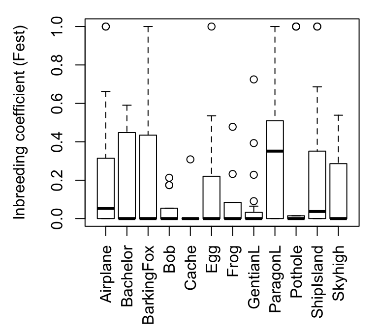

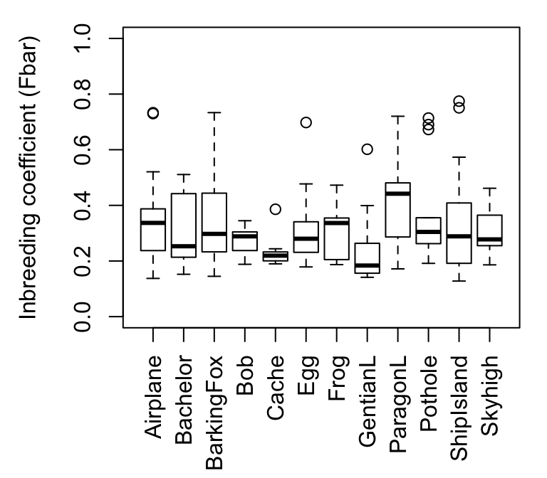

```r
par(mar=c(5.5, 4.5, 1, 1))
boxplot(Fest, las=3, ylim=c(0,1), xlab="", ylab="Inbreeding coefficient (Fest)")
boxplot(Fbar, las=3, ylim=c(0,1), xlab="", ylab="Inbreeding coefficient (Fbar)")
Mean.inbreeding.per.pop <- sapply(Fbar, mean)
```

## 4. Calculate individual- and population-level genetic distances

The degree of genetic differentiation between two populations reflects the amount of gene flow between them. Different measures of genetic distance can be used to quantify the differentiation (i.e., how different the allele frequencies are), either between pairs of individuals or pairs of populations.

This results in a distance matrix of size n x n (here, 181 x 181 for individual-level and 12 x 12 for population-level analysis). An alternative representation is an object of class ‘dist’, which contains only the (n*(n - 1)/2) values of the lower triangle of the distance matrix.

### a) Genetic distance among individuals (PopGenReport, adegenet)

```r
# Individual-level genetic distances
GD.ind.smouse <- PopGenReport::gd.smouse(Frogs.genind, verbose=FALSE)  # GenAlEx
GD.ind.propShared <- adegenet::propShared(Frogs.genind)
```

### b) Genetic distance among local populations (PopGenReport, adegenet, mmod)

```r
# Population-level genetic distances
GD.pop.propShared <- PopGenReport::pairwise.propShared(Frogs.genind)
GD.pop.Nei <- adegenet::dist.genpop(Frogs.genpop, method=1)
GD.pop.Edwards <- adegenet::dist.genpop(Frogs.genpop, method=2)
GD.pop.Reynolds <- adegenet::dist.genpop(Frogs.genpop, method=3)  # Co-ancestry coef
GD.pop.Rogers <- adegenet::dist.genpop(Frogs.genpop, method=4)
GD.pop.Provesti <- adegenet::dist.genpop(Frogs.genpop, method=5)

GD.pop.Joost <- mmod::pairwise_D(Frogs.genind, linearized = FALSE)
GD.pop.Hedrick <- mmod::pairwise_Gst_Hedrick(Frogs.genind, linearized = FALSE)
GD.pop.NeiGst <- mmod::pairwise_Gst_Nei(Frogs.genind, linearized = FALSE)
```

The argument ‘linearized = TRUE’ will linearize each distance measure x by calculating x/(1 - x). This should result in more linear relationships when plotted or correlated against geographic distance.

### c) Pair-wise Fst (hierfstat)

Pair-wise Fst values are calculated at the population level.

```r
Pairwise.fst <- hierfstat::pairwise.fst(Frogs.genind, pop = NULL,
                                        res.type = c("dist"))
```

### d) Export distance matrices

We’ll need the genetic distance matrices again in later labs, so let’s export them. Adding the package name to each matrix name helps keeping track of methods used.

Technically speaking, the two proportion of shared alleles matrices contain similarity values, not distance values. They are proportions between 0 - 1, and we can convert them to distances by subtracting them from 1.

Note: additional distance measures are available in the package ‘gstudio’. Specifically, we will use conditional genetic distance later in the course.

```r
GD.ind <- list(smouse.PopGenReport = GD.ind.smouse,
               propShared.adegent = 1 - GD.ind.propShared)

GD.pop <- list(pairwiseFst.hierfstat = Pairwise.fst,
               propShared.PopGenReport = 1 - GD.pop.propShared,
               Nei.adegenet = GD.pop.Nei,
               Edwards.adegenet = GD.pop.Edwards,
               Reynolds.adegent = GD.pop.Reynolds,
               Rogers.adegenet = GD.pop.Rogers,
               Provesti.adegent = GD.pop.Provesti,
               Joost.mmod = GD.pop.Joost,
               Hedrick.mmod = GD.pop.Hedrick,
               Nei.mmod = GD.pop.NeiGst)
```

Optional: Use ‘save’ to save an R object to your file system, and ‘load’ to read it in again. Note: the default setting is that ‘save’ will overwrite existing files with the same name.

```r
#require(here)
#if(!dir.exists(paste0(here(),"/output"))) dir.create(paste0(here(),"/output"))

#save(GD.ind, file = paste0(here(),"/output/GD.ind.RData"))
#load(paste0(here(),"/output/GD.ind.RData"))

#save(GD.pop, file = paste0(here(),"/output/GD.pop.RData"))
#load(paste0(here(),"/output/GD.pop.RData"))
```

### e) Test for isolation by distance (adegenet)

Let’s do a quick-and-dirty check for isolation by distance (IBD). For this, we need to extract the UTM coordinates per population. Here we use functions from the package ‘dplyr’ to group coordinates by population, then take their mean (they should be identical anyways).

```r
coords.pop <- Frogs.genind@other$xy %>%
  group_by(Frogs.genind@other$site$Pop) %>%
  summarize(x = mean(coords.x1, na.rm = TRUE),
            y = mean(coords.x2, na.rm = TRUE))
```

Now we can calculate geographic distance with the ‘dist’ function.

```r
Dgeo <- dist(coords.pop[,-1])
```

We’ll cycle through all population-level distance matrices. For each one, we carry out a Mantel test, and write the value of the Mantel r statistic, and its p-value, into an object ‘Result’.

```r
Result <- matrix(NA, length(GD.pop), 2,
                 dimnames=list(names(GD.pop), c("Mantel.r", "p-value")))
for(i in 1:length(GD.pop))
{
  IBD <- ade4::mantel.randtest(as.dist(GD.pop[[i]]),Dgeo)
  Result[i,] <- c(IBD$obs, IBD$pvalue)
}
Result
```

```
##                          Mantel.r p-value
## pairwiseFst.hierfstat   0.7229572   0.001
## propShared.PopGenReport 0.6481894   0.001
## Nei.adegenet            0.6911173   0.001
## Edwards.adegenet        0.7416496   0.001
## Reynolds.adegent        0.7233419   0.001
## Rogers.adegenet         0.6628601   0.001
## Provesti.adegent        0.6481894   0.001
## Joost.mmod              0.7067846   0.001
## Hedrick.mmod            0.7281155   0.001
## Nei.mmod                0.7235929   0.001
```

The Mantel r statistics range between 0.64 and 0.74, which indicates quite strong spatial structure. All tests were statistically significant at alpha = 0.05, i.e., the null hypothesis of no spatial structure could be rejected no matter which distance measure was used.

Note that we did not check, or linearize, the shape of the relationships - we’ll do a more thorough job in Week 6.

## 5. Analyze genetic structure with F statistics and AMOVA

Beyond distance effects, we may expect mountain ridges to act as barriers for gene flow. The highest ridges typically occur between drainage systems, with minor ridges between basins with a drainage system. We can use Analysis of Molecular Variance to test for such hierarchical structure. This is done in a spatially implicit way, without considering actual spatial locations or geographic distances.

### a) F statistics and analogue measures of genetic differentiation

Before considering the hierarchical sampling design, let’s quantify the overall degree of genetic differentiation among populations using F statistics, specifically Fst.

```r
# Overall F statistics (hierfstat)
hierfstat::fstat(Frogs.genind, pop = NULL, fstonly = FALSE)
```

```
##             pop        Ind
## Total 0.2003984 0.21501298
## pop   0.0000000 0.01827733
```

How to read this result:

F statistics were developed by Sewall Wright (1943) to evaluate departures from HWE for subdivided populations.

- F (Fixation index): Fixation means increased homozygosity
- FIS (Inbreeding coefficient): The probability of uniting gametes relative to gametes drawn at random from within a subpopulation (Individual within the Subpopulation)
- FST (A measure of population substructure): The probability of uniting gametes within subpopulations relative to gametes drawn at random from the entire population (Subpopulation within the Total population).
- FIT (Overall inbreeding coefficient): Inbreeding coefficient of an individual relative to the total population (Individual within the Total population).

```r
# F statistics by locus (pegas)
Frogs.pegas <- pegas::genind2loci(Frogs.genind)
pegas::Fst(Frogs.pegas)
```

```
##         Fit          Fst         Fis
## A 0.4735039  0.176828872  0.36040503
## B 0.1807003  0.195352774 -0.01820980
## C 0.7872682 -0.003069682  0.78791925
## D 0.4245470  0.434792260 -0.01812647
## E 0.1434578  0.164002266 -0.02457481
## F 0.7358985  0.128563977  0.69693531
## G 0.4004639  0.093729000  0.33845826
## H 0.1175488  0.105632420  0.01332386
```

```r
# NOTE: VERY DIFFERENT RESULTS WHEN USING MEAN OF PEGAS, SHOULD BE THE SAME)
# NEED TO CHECK ORDER?
apply(pegas::Fst(Frogs.pegas), 2, mean)
```

```
##       Fit       Fst       Fis
## 0.4079236 0.1619790 0.2670163
```

See also: https://cran.r-project.org/web/packages/mmod/vignettes/mmod-demo.pdf

```r
# Fst analogues (mmod)
mmod::diff_stats(Frogs.genind)
```

```
## $per.locus
##           Hs         Ht        Gst  Gprime_st            D
## A 0.11088553 0.13867727 0.20040591 0.24149066 0.0340993969
## B 0.40079563 0.48195801 0.16840134 0.30196792 0.1477638956
## C 0.16567061 0.17623300 0.05993425 0.07794104 0.0138106242
## D 0.33669895 0.57128787 0.41063171 0.65104853 0.3858205590
## E 0.66535587 0.78781063 0.15543679 0.49964929 0.3991912461
## F 0.01811891 0.01838739 0.01460139 0.01620123 0.0002982937
## G 0.44254462 0.49323163 0.10276511 0.19924420 0.0991916399
## H 0.66284582 0.73164862 0.09403804 0.30169397 0.2226210095
##
## $global
##          Hs          Ht     Gst_est   Gprime_st       D_het      D_mean
## 0.350364492 0.424904301 0.175427287 0.289964281 0.125171968 0.002298472
```

### b) AMOVA (using ‘poppr’ interface to ‘ade4’ and ‘pegas’ implementations)

See also: https://grunwaldlab.github.io/Population_Genetics_in_R/AMOVA.html

Here we’ll use the ‘ade4’ implementation using the ‘poppr.amova’ function. Some arguments (see help file for more detail):

- hier: Specify the hierarchy, either by pointing to the ‘hierarchy’ slot of the ‘genind’ object, or by making it explicit as ‘hier = ~ Drainage/Basin/Pop’ (without the quotes).
- within: If TRUE, variation within individuals (must be at least diploid) is assessed.
- dist: optionally, provide an individual-level distance matrix. (Use ‘within=FALSE’). The default is to calculate (1 minus) the proportion of shared alleles.
- missing: Options for dealing with missing values. The default is ‘loci’, which drops any loci with more than ‘cutoff’ proportion of missing values.
- cutoff: See ‘missing’. The default is 0.05. In this example, four of eight loci would be dropped, hence I raised the cutoff to 0.5 to keep all loci. This may affect the result.
- method: either ‘ade4’ or ‘pegas’. See help file (‘?poppr.amova’).
- nperm: this is only used for the permutation test in ‘pegas’, not ‘ade4’ (for ade4, need to run test separately, see code below).

TOTALLY DIFFERENT STATISTICAL TEST RESULTS FOR PEGAS.

```r
#amova.result.pegas <- poppr::poppr.amova(Frogs.genind, hier = ~ Drainage/Basin/Pop,
#            clonecorrect = FALSE, within = FALSE,
#  dist = NULL, squared = FALSE, correction = "quasieuclid", sep = "_",
#  filter = FALSE, threshold = 0, algorithm = "farthest_neighbor",
#  missing = "loci", cutoff = 0.5, quiet = FALSE, method = c(
#  "pegas"), nperm = 200)

amova.result.ade4 <- poppr::poppr.amova(Frogs.genind, hier = Frogs.genind@hierarchy,
            clonecorrect = FALSE, within = TRUE,
  dist = NULL, squared = FALSE, correction = "quasieuclid", sep = "_",
  filter = FALSE, threshold = 0, algorithm = "farthest_neighbor",
  missing = "loci", cutoff = 0.5, quiet = FALSE, method = c(
  "ade4"), nperm = 0)
```

```
##
##  No loci with missing values above 50% found.
```

```
## Distance matrix is non-euclidean.
```

```
## Utilizing quasieuclid correction method. See ?quasieuclid for details.
```

```r
amova.result.ade4
```

```
## $call
## ade4::amova(samples = xtab, distances = xdist, structures = xstruct)
##
## $results
##                                Df     Sum Sq   Mean Sq
## Between Drainage                3  70.636382 23.545461
## Between Basin Within Drainage   4  38.538969  9.634742
## Between Pop Within Basin        4   8.073161  2.018290
## Between samples Within Pop    169 231.144253  1.367717
## Within samples                181 227.436180  1.256553
## Total                         361 575.828945  1.595094
##
## $componentsofcovariance
##                                                Sigma          %
## Variations  Between Drainage              0.17667973  10.424592
## Variations  Between Basin Within Drainage 0.17901889  10.562609
## Variations  Between Pop Within Basin      0.02700173   1.593176
## Variations  Between samples Within Pop    0.05558200   3.279492
## Variations  Within samples                1.25655348  74.140130
## Total variations                          1.69483581 100.000000
##
## $statphi
##                           Phi
## Phi-samples-total  0.25859870
## Phi-samples-Pop    0.04235995
## Phi-Pop-Basin      0.02016352
## Phi-Basin-Drainage 0.11791863
## Phi-Drainage-total 0.10424592
```

The effect sizes are under ‘$componentsofcovariance’ in column ‘%’. Drainage and Basin each explain about 10% of the genetic variation, whereas most variation is within individuals (i.e., unexplained by the hierarchy). Let’s test the components with a permutation test.

```r
amova.test <- ade4::randtest(amova.result.ade4, nrepet=199)
amova.test
```

```
## class: krandtest lightkrandtest
## Monte-Carlo tests
## Call: randtest.amova(xtest = amova.result.ade4, nrepet = 199)
##
## Number of tests:   5
##
## Adjustment method for multiple comparisons:   none
## Permutation number:   199
##                          Test        Obs   Std.Obs   Alter Pvalue
## 1   Variations within samples 1.25655348 -9.655048    less  0.005
## 2  Variations between samples 0.05558200  1.767168 greater  0.050
## 3      Variations between Pop 0.02700173  2.563395 greater  0.020
## 4    Variations between Basin 0.17901889  1.955690 greater  0.005
## 5 Variations between Drainage 0.17667973  2.241294 greater  0.010
```

Let’s look at the numerical test results:

- There is statistically significant differentiation between drainage systems and between basins, and within samples (p-values < 0.05).
- The p-values for differentiation between populations, and between individuals (samples), are close to 0.05 and may be too close to call. Note that the exact value may vary from one run of the permutation test to the next. With only 199 replicates, the resolution of the p-value is 1/200 = 0.005. We should redo the test with a larger number of permutations (e.g. 499 or 999). This will take longer!
- Results with nrep=499: p-value < 0.05 for differentiation among populations, >0.05 among individuals.

Hence there is statistically significant differentiation at all levels, except for among frogs sampled at the same pond. The effects are largest for basin and drainage (about 10% each), whereas differentiation among populations within basins is very weak (about 1.5%).